# Chapter 14 - Adventures in Covariance

> You can think of it as a regularizing prior for correlations. This distribution has a single parameter, η, that controls how skeptical the prior is of large correlations in the matrix. When we use LKJcorr(1), the prior is flat over all valid correlation matrices. When the value is greater than 1, such as the 2 we used above, then extreme correlations are less likely.

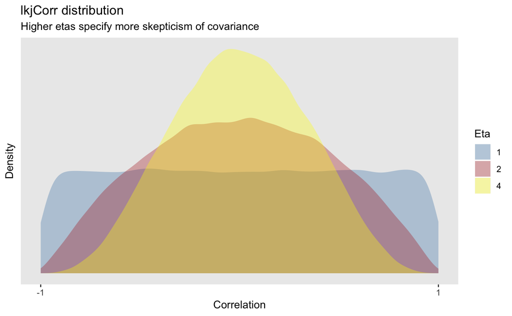

```r
n_sim <- 1e5
set.seed(133)
etas <- c(1, 2, 4)

etas %>%
  map_dfc(~ rethinking::rlkjcorr(n_sim, K = 2, eta = .x)[,1,2]) %>%
  set_names(as.character(etas)) %>%
  gather(Eta, draw) %>%
  ggplot(aes(x = draw, fill = Eta)) +
    geom_density(colour = "transparent", alpha = I(1/3)) +
    theme(panel.grid = element_blank(),
          axis.ticks.y = element_blank(),
          axis.text.y = element_blank()) +
    xlab("Correlation") + ylab("Density") +
    ggtitle("lkjCorr distribution",
            "Higher etas specify more skepticism of covariance") +
    scale_x_continuous(breaks = c(-1, 1)) +
    scale_fill_manual(values = c("steelblue", "firebrick", "yellow"))
```

With that distribution in our arsenal, lets get modeling! In our regression formula, we specify that both the intercept and time-of-day covary with cafes.

```r
get_prior(data = d, family = gaussian,
      wait ~ 1 + afternoon + (1 + afternoon | cafe))
```

|  | prior | class | coef | group | resp | dpar | nlpar | bound |
| --- | --- | --- | --- | --- | --- | --- | --- | --- |
| 1 |  | b |  |  |  |  |  |  |
| 2 |  | b | afternoon |  |  |  |  |  |
| 3 | lkj(1) | cor |  |  |  |  |  |  |
| 4 |  | cor |  | cafe |  |  |  |  |
| 5 | student_t(3, 3, 10) | Intercept |  |  |  |  |  |  |
| 6 | student_t(3, 0, 10) | sd |  |  |  |  |  |  |
| 7 |  | sd |  | cafe |  |  |  |  |
| 8 |  | sd | afternoon | cafe |  |  |  |  |
| 9 |  | sd | Intercept | cafe |  |  |  |  |
| 10 | student_t(3, 0, 10) | sigma |  |  |  |  |  |  |

```r
 b13.1 <-
  brm(data = d, family = gaussian,
      wait ~ 1 + afternoon + (1 + afternoon | cafe),
      prior = c(prior(normal(0, 10), class = Intercept),
                prior(normal(0, 10), class = b),
                prior(cauchy(0, 2) , class = sd),
                prior(cauchy(0, 2) , class = sigma),
                prior(lkj(2), class = cor)),
      sample_prior = "yes", refresh = 0,
      iter = 5000, warmup = 2000, chains = 2, cores = 2)
summary(b13.1)
```

```
 Family: gaussian
  Links: mu = identity; sigma = identity
Formula: wait ~ 1 + afternoon + (1 + afternoon | cafe)
   Data: d (Number of observations: 2000)
Samples: 2 chains, each with iter = 5000; warmup = 2000; thin = 1;
         total post-warmup samples = 6000

Group-Level Effects:
~cafe (Number of levels: 200)
                         Estimate Est.Error l-95% CI u-95% CI Eff.Sample Rhat
sd(Intercept)                1.01      0.05     0.91     1.12       1168 1.00
sd(afternoon)                0.46      0.03     0.39     0.53       2683 1.00
cor(Intercept,afternoon)    -0.68      0.05    -0.77    -0.57       3072 1.00

Population-Level Effects:
          Estimate Est.Error l-95% CI u-95% CI Eff.Sample Rhat
Intercept     3.50      0.07     3.35     3.65        598 1.00
afternoon    -0.98      0.04    -1.06    -0.91       1444 1.00

Family Specific Parameters:
      Estimate Est.Error l-95% CI u-95% CI Eff.Sample Rhat
sigma     0.51      0.01     0.49     0.52       6895 1.00

Samples were drawn using sampling(NUTS). For each parameter, Eff.Sample
is a crude measure of effective sample size, and Rhat is the potential
scale reduction factor on split chains (at convergence, Rhat = 1).
```

Lets examine the learned correlation between our slopes and intercepts

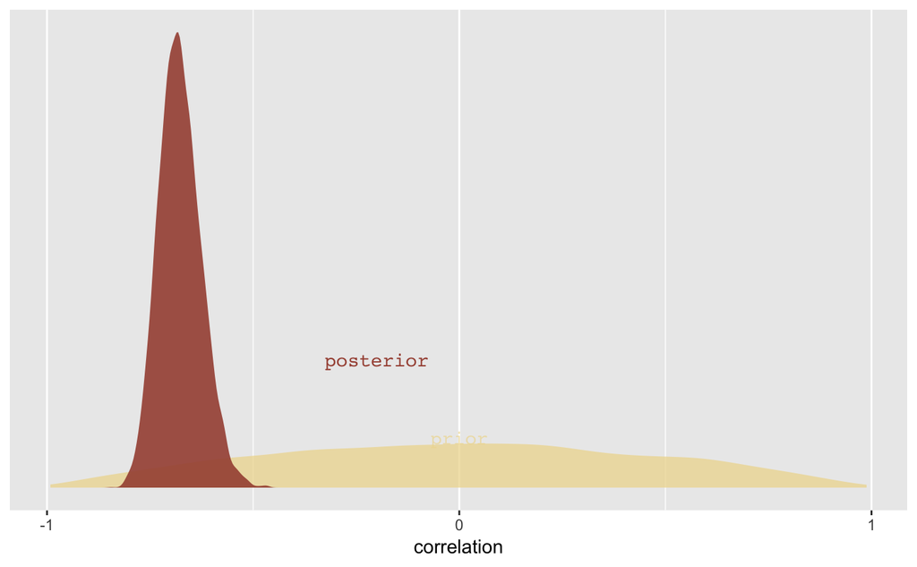

```r
post <- posterior_samples(b13.1)

post %>%
  ggplot(aes(x = cor_cafe__Intercept__afternoon)) +
  geom_density(aes(x = prior_cor_cafe),
               color = "transparent", fill = "#EEDA9D", alpha = 3/4) +
  geom_density(color = "transparent", fill = "#A65141", alpha = 9/10) +
  annotate("text", label = "posterior",
           x = -0.2, y = 2.2,
           color = "#A65141", family = "Courier") +
  annotate("text", label = "prior",
           x = 0, y = 0.85,
           color = "#EEDA9D", alpha = 2/3, family = "Courier") +
  scale_y_continuous(NULL, breaks = NULL) +
  scale_x_continuous(breaks = c(-1, 0, 1)) +
  xlab("correlation")
```

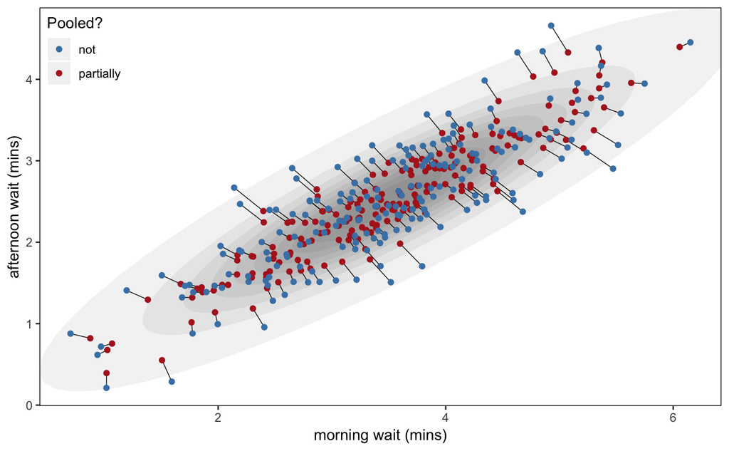

```r
# Extract group level coefficients like so:
# coefficients$groupterm[allrows,estimates_only,parameters 1 and 2]
partially_pooled_estimates <-
  coef(b13.1)$cafe[ , 1, 1:2] %>%
  as_tibble() %>%
  rename(morning   = Intercept) %>%
  mutate(afternoon = morning + afternoon,
         cafe      = 1:n()) %>%
  select(cafe, everything())

# Compute unpooled estimates directly from data
un_pooled_estimates <-
  d %>%
  group_by(afternoon, cafe) %>%
  summarise(mean = mean(wait)) %>%
  ungroup() %>%
  mutate(afternoon = ifelse(afternoon == 0, "morning", "afternoon")) %>%
  spread(key = afternoon, value = mean)

estimates <-
  bind_rows(partially_pooled_estimates, un_pooled_estimates) %>%
  mutate(pooled = rep(c("partially", "not"), each = n() / 2))

ggplot(data = estimates, aes(x = morning, y = afternoon)) +
  # Nesting `stat_ellipse()` within `mapply()` is a less redundant way to produce the
  # ten-layered semitransparent ellipses we did with ten lines of `stat_ellipse()`
  # functions in the previous plot
  mapply(function(level) {
    stat_ellipse(geom  = "polygon", type = "norm",
                 size  = 0, alpha = 1/15,
                 level = level)
    },
    # Enter the levels here
    level = c(seq(from = 1/10, to = 9/10, by = 1/10), .99)) +
  geom_line(aes(group = cafe), size = 1/4) +
  geom_point(aes(group = cafe, color = pooled)) +
  scale_color_manual("Pooled?",
                     values = c("steelblue", "firebrick")) +
  coord_cartesian(xlim = range(estimates$morning),
                  ylim = range(estimates$afternoon)) +
  theme(panel.background = element_rect(fill = "transparent", color = "black"),
        panel.grid = element_blank(),
        legend.position = c(0, 1),
        legend.justification = c(0, 1),
        legend.background = element_blank()) +
  labs(x = "morning wait (mins)",
       y = "afternoon wait (mins)")
```